# Generative Art

- Show All Code
- Hide All Code
- View Source

Author

Eva Dykaar

```r
library(tidyverse)
```

## Piece Number One

```r
# Source for random numbers: https://art-from-code.netlify.app/day-1/session-1/
set.seed(1000)
n <- 500
num <- tibble(
  x0 = runif(n),
  y0 = runif(n),
  x1 = x0 + runif(n, min = -1, max = 1),
  y1 = y0 + runif(n, min = -1, max = 1),
  shade = runif(n),
  size = runif(n)
)
```

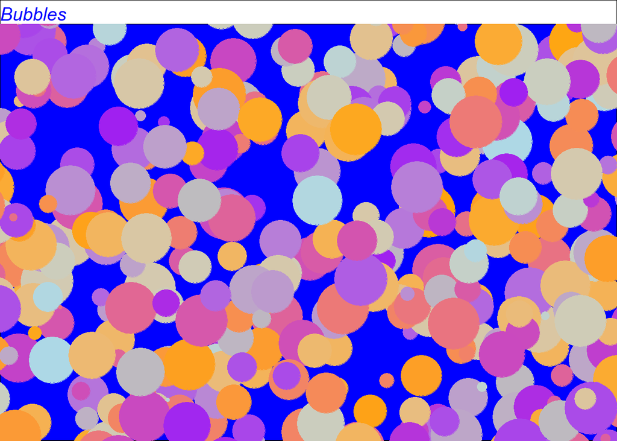

```r
# Source for base code: https://art-from-code.netlify.app/day-1/session-1/
# Source for changing plot background: https://r-graph-gallery.com/240-custom-layout-background-ggplot2.html
num |>
  ggplot(aes(
    x = x0,
    y = y0,
    xend = x1,
    yend = y1,
    colour = shade,
    size = size
  )) +
  geom_point(show.legend = FALSE) +
  scale_y_continuous(expand = c(0, -1)) +
  scale_x_continuous(expand = c(0, -1)) +
  scale_size(range = c(0, 20)) +
  theme_void() +
  scale_colour_gradientn(colours = c("lightblue", "orange", "purple", "grey")) +
  theme(
    plot.background = element_rect(fill = "white"),
    panel.background = element_rect(fill = "blue")
  ) +
    labs(title = "Bubbles") +
    theme(
      plot.title = element_text(
        face = "italic",
        color = "blue",
        size = 15,
      ))
```

#### Museum Description

This piece shows circles placed around the canvas. With the bright colors in this work it is meant to represent summer and imagery of the pool and blowing bubbles during this time. This work is inspired by Danielle Navarro and her work and also Jackson Pollock’s splatter painting work that demonstrates the use of negative and positive space in seemly random artwork is very important to creating a cohesive piece.

#### Code Choices

In this code I wanted to make the buddles fill up the whole page and used a combination of the scale_x_continous, scale_y_continuous, and scale_size to achieve this look. I also used the colors light blue, orange, purple, and grey with a blue background to remind the audience of summer.

## Piece Number Two

```r
# Show polygon base function: https://art-from-code.netlify.app/day-1/session-3/
# Note I made changes to the function!

show_polygon <- function(polygon) {

  pic <- ggplot(polygon, aes(x, y)) +
    geom_polygon(colour = "darkred", fill = "pink", show.legend = FALSE, linewidth = 1) +
    coord_equal() +
    theme_void() +
    labs(title = "    Connected Hearts") +
    theme(
      plot.title = element_text(
        face = "italic",
        color = "darkred",
        size = 15,
      ))

  return(pic)
}
```

```r
# Heart x and y base function: https://art-from-code.netlify.app/day-1/session-3/
# Note I made changes to the function!

# heart_x function
heart_x <- function(angle) {
  x <- (16 * sin(angle) ^ 3) / 20
  return(x - mean(x))
}

# heart_y function
heart_y <- function(angle) {
  y <- (13 * cos(angle) - 5 * cos(2 * angle) - 2 * cos(3 * angle) -
          cos(4 * angle)) / 20
  return(y - mean(y))
}
```

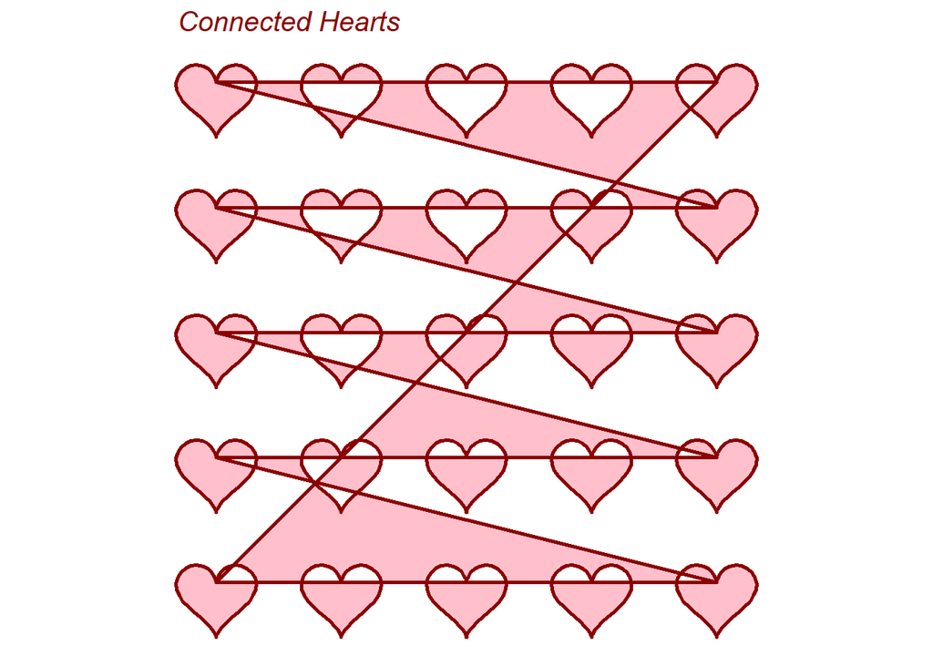

```r
# Source: used chatGPT to scale down the size of the hearts and to create a grid out of the hearts

# scale factor for hearts
scale_factor <- 0.4

# creating the heart shape with the smaller scale
heart_shape <- tibble(
  angle = seq(0, 2 * pi, length.out = 50),
  x = heart_x(angle) * scale_factor,
  y = heart_y(angle) * scale_factor
)

# creating grid
hearts_grid <- expand.grid(x_shift = seq(1, 5, by = 1),
                           y_shift = seq(1, 5, by = 1)) |>
  as_tibble() |>
  rowwise() |>
  mutate(data = list(tibble(
    x = heart_shape$x + x_shift,
    y = heart_shape$y + y_shift
  ))) |>
  unnest(data)

show_polygon(hearts_grid)
```

#### Museum Description

This piece shows hearts connected together with a pink color filling the shapes that appear in between the lines. This piece was inspired from Danielle Navarro and her work with polygons. Each heart is fulled to a certain degree depending on its place in the grid.

#### Code Choices

In this code I wanted the hearts to look cartoon like so I used a darker pink outline and made the linewidth thick to get that effect. I also made the hearts wide to contribute to the cartoon effect. By sequencing from 1 to 5 for both the x and y values this creates a 5 by 5 grid.